# PEC 2 Estadistica Avanzada

Ramon Soto

2022-04-13

# 1 Carga de datos

```r
library(kableExtra)
setwd("D:/uoc/estadistica avanzada/PEC2/" );
Salarios <-
  read.table("CensusIncome_clean.csv",
             header=TRUE, stringsAsFactors=TRUE, sep=",", na.strings="NA", dec=".",
             strip.white=TRUE)

#Se comprueba que se ha leido bien la tabla

str(Salarios)
```

```
## 'data.frame':    32553 obs. of  12 variables:
##  $ CS_ID         : Factor w/ 32553 levels "CS1","CS10","CS100",..: 1 11112 22221 25900 27011 28122 29231 30338 31445 2 ...
##  $ age           : int  50 38 53 28 37 49 52 31 42 37 ...
##  $ workclass     : Factor w/ 4 levels "Government","Other/Unknown",..: 4 3 3 3 3 3 4 3 3 3 ...
##  $ education_num : int  13 9 7 13 14 5 9 14 13 10 ...
##  $ marital_status: Factor w/ 5 levels "D","M","S","W",..: 2 1 2 2 2 2 2 3 2 2 ...
##  $ relationship  : Factor w/ 6 levels "Husband","Not-in-family",..: 2 1 2 1 6 6 2 1 2 1 ...
##  $ occupation    : Factor w/ 6 levels "Blue-Collar",..: 6 1 1 3 6 5 6 3 6 6 ...
##  $ race          : Factor w/ 5 levels "Amer-Indian-Eskimo",..: 5 5 3 3 5 3 5 5 5 3 ...
##  $ gender        : Factor w/ 2 levels "f","m": 2 2 2 1 1 1 2 1 2 2 ...
##  $ hours_per_week: num  13.5 40 40.5 40 40.5 16 45 50.5 40 50 ...
##  $ income        : num  52 51.7 50.1 44.2 0.1 ...
##  $ education_cat : Factor w/ 4 levels "Postuniversitaria",..: 4 3 3 4 1 2 3 1 4 4 ...
```

# 2 Edad

## 2.1 Distribucion de edades

Haciendo un histograma de frecuencias puede verse cierta similitud con una distribución normal pero con una asimetría positiva

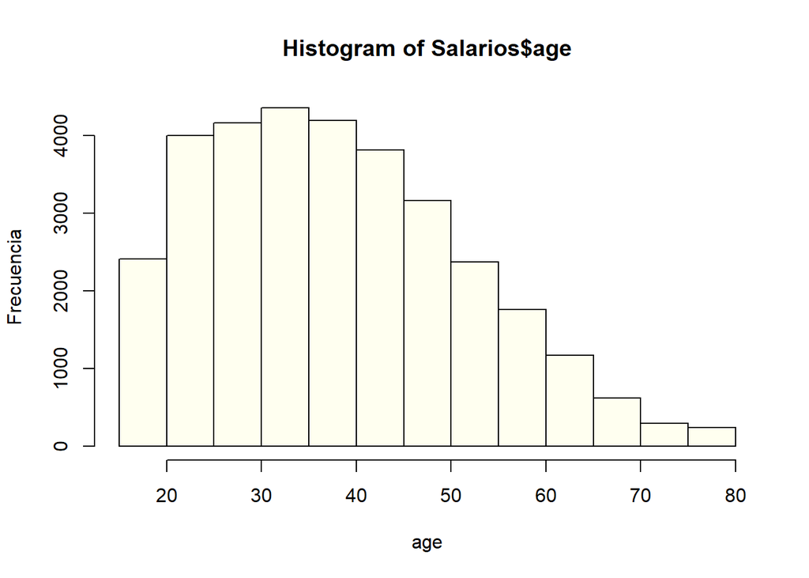

## 2.2 Normalidad

Considerando el teorema del límite central, dado el tamaño de la muestra de edades que disponemos, podemos asumir que este teorema establece que el contraste de hipótesis sobre la media de una muestra se aproxima a una distribución normal

Otra alternativa es usar el test de Shapiro. Para ello seleccionamos una subconjunto con 5000 muestras.

```r
age_sample<-sample(Salarios$age,5000)
shapiro.test(age_sample)
```

```
##
##  Shapiro-Wilk normality test
##
## data:  age_sample
## W = 0.96865, p-value < 2.2e-16
```

## 2.3 Intervalo de confianza,cálculos e interpretación

Definimos la función Intervalo de confianza de la media y posteriormente se hacen dos llamadas con NC=0.9 y NC=0.95

El intervalo de confianza para un valor de NC indica que la media de la población se encuentra en dicho intervalo con una confianza del NC*100%

Por eso cuando aumentamos el valor del NC aumenta el rango del intervalo

```r
IC <- function( x, NC=0.9 ){
  alfa<-1-NC
  n<-length(x)
  desv<-sd(x)
  media<-mean(x)

  #Z contiene el valor para el que se cumple que P(X>z)=alfa/2
  z<-qnorm (alfa/2,lower.tail=FALSE)

  #Se devuelven los dos valores del intervalo

  return(c(media-(z*desv/sqrt(n)),media+(z*desv/sqrt(n))))

}

IC(Salarios$age,0.9)
```

```
## [1] 38.42642 38.67333
```

```r
IC(Salarios$age,0.95)
```

```
## [1] 38.40277 38.69698
```

# 3 Salario

## 3.1 Pregunta

¿La media poblacional del salario de los trabajadores autónomos es inferior a la del resto de trabajadores?

## 3.2 Hipótesis

Planteamos la hipótesis nula y la hipótesis alternativa:

H0 mu1=mu2

H1 mu1<mu2

siendo mu1 la media del salario de las personas self-employed y mu2 la media del resto de la población

## 3.3 Test a aplicar

Aquí podemos aplicar un contraste de hipótesis de dos muestras independientes (self-employed y el resto de categorías profesionales) sobre la media. Como no tenemos información la varianza es desconocida.

Para ver si las varianzas son iguales o no Hacemos un F-Test usamos la función var.test, que hace el siguiente contraste de hipótesis bilateral con las varianzas de cada muestra:

H0 var1=var2

H1 var1!=var2

```r
muestra1<-Salarios$income[Salarios$workclass=="Self-Employed"]
muestra2<-Salarios$income[Salarios$workclass!="Self-Employed"]

var.test(muestra1, muestra2)
```

```
##
##  F test to compare two variances
##
## data:  muestra1 and muestra2
## F = 0.63242, num df = 3656, denom df = 28895, p-value < 2.2e-16
## alternative hypothesis: true ratio of variances is not equal to 1
## 95 percent confidence interval:
##  0.6026580 0.6642595
## sample estimates:
## ratio of variances
##          0.6324152
```

## 3.4 Cálculo

A continuación definimos la función que nos devolverá el p valor el valor observado y el valor crítico y la invocamos dos veces con un NC de 0.9 y de 0.95 respectivamente.

Comparamos con la función t.test para comprobar que coinciden el p valor y el valor observado

```r
varianzas <- function( x1, x2, NC=0.95 ){



  alfa<-1-NC
  n1<-length(x1)
  n2<-length(x2)
  grados<-n1+n2-2 #estos son los grados de la función t de student que usaremos para calcular el p valor y el valor crítico
  s1<-sd(x1)
  s2<-sd(x2)
  m1<-mean(x1)
  m2<-mean(x2)
  S<-sqrt(((n1-1)*s1^2+ (n2-1)*s2^2)/(n1+n2-2)) #esta es la desviación típica común
  z_obs<-(m1-m2)/(S*sqrt((1/n1)+(1/n2)))
  z_crit<-qt(alfa,df=grados,lower.tail = TRUE)
  p_valor<-pt(z_obs,df=grados,lower.tail = TRUE)


  return (data.frame(NC=NC,z_obs=z_obs,z_crit=z_crit,p_valor=p_valor))


}





tabla1<- rbind(varianzas(muestra1,muestra2,0.90),
varianzas(muestra1,muestra2,0.95))


tabla1 %>%
  kbl() %>%
  kable_styling()
```

| NC | z_obs | z_crit | p_valor |
| --- | --- | --- | --- |
| 0.90 | 5.77555 | -1.281578 | 1 |
| 0.95 | 5.77555 | -1.644900 | 1 |

```r
t.test(muestra1,muestra2,alternative="less", var.equal=TRUE,conf.level=0.9)
```

```
##
##  Two Sample t-test
##
## data:  muestra1 and muestra2
## t = 5.7756, df = 32551, p-value = 1
## alternative hypothesis: true difference in means is less than 0
## 90 percent confidence interval:
##       -Inf 0.8790212
## sample estimates:
## mean of x mean of y
##  49.39123  48.67183
```

```r
t.test(muestra1,muestra2,alternative="less", var.equal=TRUE)
```

```
##
##  Two Sample t-test
##
## data:  muestra1 and muestra2
## t = 5.7756, df = 32551, p-value = 1
## alternative hypothesis: true difference in means is less than 0
## 95 percent confidence interval:
##       -Inf 0.9242759
## sample estimates:
## mean of x mean of y
##  49.39123  48.67183
```

## 3.5 Conclusión

En ambos casos el p valor es no es menor que el nivel de significancia y además el valor observado es mayor que el valor crítico.

Por tanto no podemos rechazar la hipótesis nula de que ambas medias poblacionales son iguales

# 4 Proporción de Self-Employed

## 4.1 Pregunta

¿La proporción de personas self-employed en la población es superior al 10%?

## 4.2 Hipótesis

El contraste de hipótesis seria el siguiente:

H0: p=0.1

H1: p>0.1

donde p es la proporcion de las personas self-employed

## 4.3 Analisis visual

En la grafica de abajo observamos que en esta muestra que las personas Self-emloyed superan el 10%

```r
library(lessR)
```

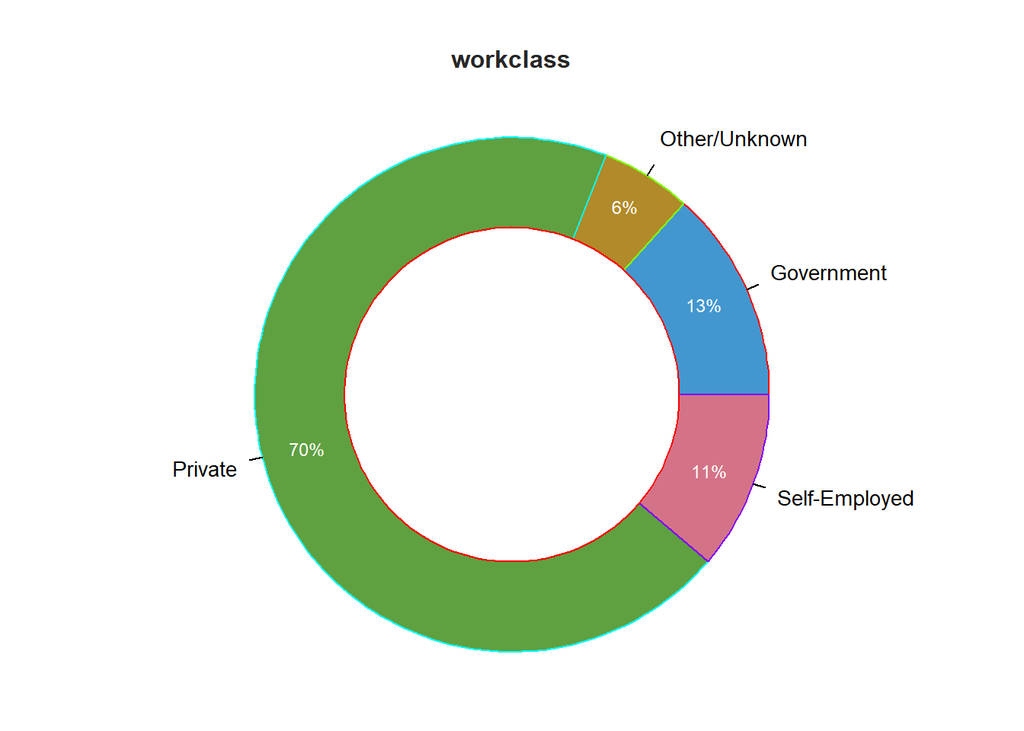

```
## >>> Suggestions
## PieChart(workclass, hole=0)  # traditional pie chart
## PieChart(workclass, values="%")  # display %'s on the chart
## PieChart(workclass)  # bar chart
## Plot(workclass)  # bubble plot
## Plot(workclass, values="count")  # lollipop plot
##
## --- workclass ---
##
##                Government  Other/Unknown  Private  Self-Employed       Total
## Frequencies:         4349           1855    22692           3657       32553
## Proportions:        0.134          0.057    0.697          0.112       1.000
##
## Chi-squared test of null hypothesis of equal probabilities
##   Chisq = 35109.623, df = 3, p-value = 0.000
```

```r
PieChart(workclass, data=Salarios, xlab="", ylab="", main="workclass",
         col=rainbow(4), scale="percent")
```

## 4.4 Contraste

Planteamos un contraste de hipótesis sobre la proporción para muestras suficientemente grandes Se trata por tanto de un contraste unilateral por la derecha.

El estadístico de contraste que usaremos lo definiremos en la función “proporción” y tendrá como parámetros la proporción de la muestra, el parámetro poblacional (con valor 0,1) y el tamaño de la muestra

Este estadístico seguirá una distribución normal bajo la hipótesis nula

```r
proporcion <- function( p_muestra,n, p0, NC=0.95 ){



  alfa<-1-NC
  #calculo del valor observado con el estadístico
  z_obs<-(p_muestra-p0)/sqrt(p0*(1-p0)/n)
  #como el estadisstico sigue una distribucion normal
  #para calcular el valor critico  y el p valor se usan pnorm y qnorm
  z_crit<-qnorm(alfa,lower.tail = FALSE)
  p_valor<-pnorm(z_obs,lower.tail = FALSE)


  return (data.frame(NC=NC,z_obs=z_obs,z_crit=z_crit,p_valor=p_valor))


}
```

## 4.5 Cálculo y conclusiones

El p valor es menor que el nivel de significancia (0.05) Y el valor observado es mayor que el valor critico

Esto nos lleva a rechazar la hipótesis nula y a afirmar que la proporción de self employed en la población es superior al 10% con un nivel de confianza del 95%

```r
#usamos muestra1, que contiene los self-employed
n<-nrow(Salarios)
p_muestra<-length(muestra1)/n

tabla2<-proporcion(p_muestra,n,0.1)

tabla2 %>%
  kbl() %>%
  kable_styling()
```

| NC | z_obs | z_crit | p_valor |
| --- | --- | --- | --- |
| 0.95 | 7.421387 | 1.644854 | 0 |

# 5 Proporcion de Self-Employed en mujeres y hombres

## 5.1 Pregunta

¿La proporción de Self-Employed entre las mujeres de la población es menor a la proporción de Self-Employed entre los hombres de la población?

## 5.2 Visualización

Hacemos una gráfica de barras en la que se puede apreciar para la muestra dada que la porporción de Self-Employed dentro del subconjunto de mujeres es claramente menor que dentro del subjonjunto de hombres

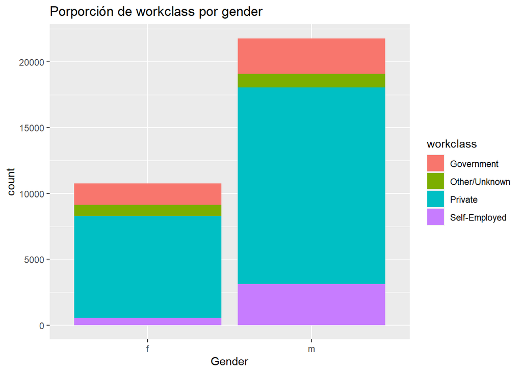

```r
if (!require('ggplot2')) install.packages('ggplot2'); library('ggplot2')
ggplot(data=Salarios,aes(x=gender,fill=workclass))+geom_bar()+ggtitle("Porporción de workclass por gender")+labs(x="Gender")
```

## 5.3 Hipótesis:

H0: p1=p2

H1: p1<p2

siendo p1 proporción de Self-Employed entre las mujeres y p2 la correspondiente entre los hombres de la población

## 5.4 Test

Haremos por tanto un contrste de proporción sobre dos muestras.

Considerararemos que las muestras son lo suficiente grandes. Se trata de un contraste unilateral por la izquierda.

El estadístico de contraste lo definiremos en la función “proporciones” y recibirá como parámetros las proporciones y tamaños de cada muestras así como el nivel de confianza

## 5.5 Cálculo

```r
proporciones <- function( p1,p2,n1, n2, NC=0.97 ){


  alfa<-1-NC


  p<-(n1*p1 + n2*p2) / (n1+n2)
  z_obs<-(p1-p2)/( sqrt(p*(1-p)*(1/n1+1/n2)) )
  z_crit<-qnorm(alfa, lower.tail=TRUE)
  p_valor<-pnorm(z_obs,lower.tail = TRUE)


  return (data.frame(NC=NC,z_obs=z_obs,z_crit=z_crit,p_valor=p_valor))


}

#Aquí preparamos  los parámetros

xf<-Salarios[(Salarios$gender=="f"),]
xm<-Salarios[(Salarios$gender=="m"),]

self_f<-xf[(xf$workclass=="Self-Employed"),]
self_m<-xm[(xm$workclass=="Self-Employed"),]
n1<-nrow(xf)
n2<-nrow(xm)
p1<-nrow(self_f)/n1
p2<-nrow(self_m)/n2

#llamamos a la función y  presentamos los resultados en una tabla



tabla<- proporciones(p1,p2,n1,n2)

tabla %>%
  kbl() %>%
  kable_styling()
```

| NC | z_obs | z_crit | p_valor |
| --- | --- | --- | --- |
| 0.97 | -25.20201 | -1.880794 | 0 |

```r
#contrastamos resultados con prop.test
success<-c( p1*n1, p2*n2)
 nn<-c(n1,n2)
prop.test(success, nn, alternative="less", correct=FALSE)
```

```
##
##  2-sample test for equality of proportions without continuity
##  correction
##
## data:  success out of nn
## X-squared = 635.14, df = 1, p-value < 0.00000000000000022
## alternative hypothesis: less
## 95 percent confidence interval:
##  -1.0000000 -0.0885477
## sample estimates:
##     prop 1     prop 2
## 0.04959599 0.14334894
```

## 5.6 Conclusión

El p valor es inferior al nivel de significancia y también el valor observado es menor que el valor critico estando por tanto fuera del rango de aceptación de la hipótesis nula

En este caso podemos afirmar con un nivel de confianza del 97% que la proporción de self-employed en las mujeres es menor a la proporción de self-employed en los hombres

# 6 Dependencia Self-Employed- Gender

## 6.1 Pregunta

¿ Las variables Self-Employed y Gender están relacionadas o son indenpendientes?

## 6.2 Hipótesis:

H0: Self-Employed y Gender son independientes

H1: Self-Employed y Gender están relacionadas

## 6.3 Test

Aplicaremos el del test chi cuadrado.Primero construiremos la tabla de contingencia.

A partir de ella se calculan los valores esperados si las variables no estuvieran relacionadas

Con estos datos se calcula la formula que nos dará el valor observado

Esta sigue una distribución Chi cuadrado con 1 grado de libertad.

```r
Salarios$isSE <- ifelse( Salarios$workclass=="Self-Employed", "Self-Employed","Other")
tc<-table( Salarios$isSE, Salarios$gender )
tc
```

```
##
##                     f     m
##   Other         10233 18663
##   Self-Employed   534  3123
```

```r
testchicuadrado <- function( tc, NC=0.97 ){
  n<-sum(tc)
  e<-matrix(nrow = 2, ncol = 2)
  e[1,1]<-sum(tc[1,])*sum(tc[,1])/n
  e[1,2]<-sum(tc[1,])*sum(tc[,2])/n
  e[2,1]<-sum(tc[2,])*sum(tc[,1])/n
  e[2,2]<-sum(tc[2,])*sum(tc[,2])/n

  alfa<-1-NC

  z_obs<-sum((tc-e)^2/e)


  p_valor<-pchisq(z_obs,df=1,lower.tail=FALSE)


  return (data.frame(z_obs=z_obs,p_valor=p_valor))


}




tabla<- testchicuadrado(tc)

tabla %>%
 kbl() %>%
  kable_styling()
```

| z_obs | p_valor |
| --- | --- |
| 635.1414 | 0 |

```r
chisq.test(tc, correct=TRUE) #usamos esta función para cotejar
```

```
##
##  Pearson's Chi-squared test with Yates' continuity correction
##
## data:  tc
## X-squared = 634.2, df = 1, p-value < 0.00000000000000022
```

## 6.4 Cálculo y conclusión

Vemos comparando con chisq.test que que se obtiene un valor observado aproximado. El p valor es muy pequeño y podemos rechazar la hipótesis nula.

Por tanto con un nivel de confianza del 97% podemos afirmar que las variables no son independientes, confirmando el apartado anterior

# 7 Resumen

```r
library(kableExtra)


preguntas<- c("Intervalo de confianza de la media de edad al 95%",

              "¿La media poblacional del salario de  los trabajadores autónomos es inferior a la  del resto de trabajadores?",

              "¿La proporción de personas self-employed en la población es superior al 10%?",

              "¿La proporción de Self-Employed entre las mujeres de la población es menor a la proporción de Self-Employed entre los hombres de la población?",

              "¿ Las variables Self-Employed y Gender están relacionadas o son indenpendientes?"

              )



intervalo<-c("(38.40277, 38.69698)","","","","")
nivelconf<-c("0.95","0.95","0.95","0.97","0.97")
pvalor<-c("","1","0","0","0")
ZOBS<-c("","5.77555","7.421387","-25.20201","635.1414")
ZCRIT<-c("","-1.644900","1.644854","-1.880794","")

Conclusiones<-c("El intervalo de confianza para un valor de NC indica que  la media de la población se encuentra en dicho intervalo con una confianza del NC*100%",
                "Para los NC de 90 y 95% no podemos rechazar la hipótesis nula de que ambas medias poblacionales son iguales",
                "Rechazamos la hipoteis nula y afirmar que la proporción de self employed en la población es superior al 10% con un nivel de confianza del 95%",
                "Podemos afirmar con un nivel de confianza del 97% que la proporción de self-employed en las mujeres es menor a la proporción de self-employed en los hombres",
                "Con un nivel de confianza del 97% podemos afirmar que las variables no son independientes"
                )

resumen<-data.frame(apartado=c(2,3,4,5,6),
           preguntas=preguntas,
           intervalo=intervalo,
           nivelconf=nivelconf,
           pvalor=pvalor,
           ZOBS=ZOBS,
           ZCRIT=ZCRIT,

           conclusiones=Conclusiones
           )




resumen %>%
  kbl("html") %>%
  kable_styling(full_width = F)
```

| apartado | preguntas | intervalo | nivelconf | pvalor | ZOBS | ZCRIT | conclusiones |
| --- | --- | --- | --- | --- | --- | --- | --- |
| 2 | Intervalo de confianza de la media de edad al 95% | (38.40277, 38.69698) | 0.95 |  |  |  | El intervalo de confianza para un valor de NC indica que la media de la población se encuentra en dicho intervalo con una confianza del NC*100% |
| 3 | ¿La media poblacional del salario de los trabajadores autónomos es inferior a la del resto de trabajadores? |  | 0.95 | 1 | 5.77555 | -1.644900 | Para los NC de 90 y 95% no podemos rechazar la hipótesis nula de que ambas medias poblacionales son iguales |
| 4 | ¿La proporción de personas self-employed en la población es superior al 10%? |  | 0.95 | 0 | 7.421387 | 1.644854 | Rechazamos la hipoteis nula y afirmar que la proporción de self employed en la población es superior al 10% con un nivel de confianza del 95% |
| 5 | ¿La proporción de Self-Employed entre las mujeres de la población es menor a la proporción de Self-Employed entre los hombres de la población? |  | 0.97 | 0 | -25.20201 | -1.880794 | Podemos afirmar con un nivel de confianza del 97% que la proporción de self-employed en las mujeres es menor a la proporción de self-employed en los hombres |
| 6 | ¿ Las variables Self-Employed y Gender están relacionadas o son indenpendientes? |  | 0.97 | 0 | 635.1414 |  | Con un nivel de confianza del 97% podemos afirmar que las variables no son independientes |